# ASM - Exercise week 10

Tobias Krüger & Anne-Kathleen Malchow

May 7, 2021

# 11H2

The data contained in `library(MASS);data(eagles)` are records of salmon pirating attempts by Bald Eagles in Washington State. See `?eagles` for details. While one eagle feeds, sometimes another will swoop in and try to steal the salmon from it. Call the feeding eagle the “victim” and the thief the “pirate”. Use the available data to build a binomial GLM of successful pirating attempts.

## (a)

Q: Consider the following model:

$$\begin{align*}
y_i &\sim {\sf Binomial}(n_i, p_i) \\
{\sf log} {{p_i}\over{1-p_i}} &= \alpha + \beta_P \, P_i + \beta_V \, V_i + \beta_A \, A_i \\
\alpha &\sim {\sf Normal}(0, 1.5) \\
\beta_P &\sim {\sf Normal}(0, 0.5) \\
\beta_V &\sim {\sf Normal}(0, 0.5) \\
\beta_A &\sim {\sf Normal}(0, 0.5)
\end{align*}$$

where $y$ is the number of successful attempts, $n$ is the total number of attempts, $P$ is a dummy variable indicating whether or not the pirate had large body size, $V$ is a dummy variable indicating whether or not the victim had large body size, and finally $A$ is a dummy variable indicating whether or not the pirate was an adult.

Fit the model above to the eagles data, using `brms`.

A:

Load the dataset:

```r
library(brms)
library(ggplot2)
library(MASS)
data(eagles)
d <- eagles
str(d)
```

```
## 'data.frame':    8 obs. of  5 variables:
##  $ y: int  17 29 17 20 1 15 0 1
##  $ n: int  24 29 27 20 12 16 28 4
##  $ P: Factor w/ 2 levels "L","S": 1 1 1 1 2 2 2 2
##  $ A: Factor w/ 2 levels "A","I": 1 1 2 2 1 1 2 2
##  $ V: Factor w/ 2 levels "L","S": 1 2 1 2 1 2 1 2
```

The equation in the book is clearly suggesting an *indicator_variable* formulation, despite all that was said about the benefits of the *index_variable* formulation for setting priors. But it turns out that index parameterisation is tricky when there’s more than one categorical predictor, especially when it comes to interactions later on (part (c) below). So we translate the equation above in `brms` as follows:

```r
m.11H2.1 <-
  brm(data = d,
      # set link function explicitly
      family = binomial(link = "logit"),
      formula = y | trials(n) ~ 1 + P + V + A,
      prior = c(prior(normal(0,1.5), class = Intercept),
                prior(normal(0,0.5), class = b)))
```

To set the link function, we use the options that are provided by `brms` for each family. Find an overview of all families and their implemented link functions under https://rdrr.io/cran/brms/man/brmsfamily.html. Some distributions need more than one link function - one for each parameter; see for example the `?negbinomial`. In our case, we don’t have to explicitly set the link function because the logit is the default link for the binomial family; this is assumed if no link function is specified.

## (b)

Q: Now interpret the estimates. Then plot the posterior predictions.

Compute and display both

1. the predicted *probability* of success and its 89% interval for each row ($i$) in the data, as well as
2. the predicted success *count* and its 89% interval.

What different information does each type of posterior prediction provide?

A:

```r
summary(m.11H2.1)
```

```
##  Family: binomial
##   Links: mu = logit
## Formula: y | trials(n) ~ 1 + P + V + A
##    Data: d (Number of observations: 8)
## Samples: 4 chains, each with iter = 2000; warmup = 1000; thin = 1;
##          total post-warmup samples = 4000
##
## Population-Level Effects:
##           Estimate Est.Error l-95% CI u-95% CI Rhat Bulk_ESS Tail_ESS
## Intercept     0.90      0.31     0.31     1.49 1.00     4371     3285
## PS           -1.63      0.31    -2.25    -1.05 1.00     4076     3109
## VS            1.70      0.32     1.08     2.33 1.00     4095     2673
## AI           -0.65      0.31    -1.26    -0.04 1.00     4312     2989
##
## Samples were drawn using sampling(NUTS). For each parameter, Bulk_ESS
## and Tail_ESS are effective sample size measures, and Rhat is the potential
## scale reduction factor on split chains (at convergence, Rhat = 1).
```

The Intercept ($\alpha$) represents the so called “baseline” (here PL, VL, AA). The parameters PS, VS and AI stand for the change from the baseline when PL changes to PS, VS to VL and/or AA to AI. Remember that internally the binary indicator variables are scaled to 0 and 1. Looking at the parameter estimates, we find that small pirates have consistently lower log-odds than large pirates (PS is negative). Attacking a small victim increases the log-odds significantly (compared to a large victim; VS is positive). And being immature reduces the pirate’s log-odds (compared to being adult; AI is negative).

The only thing to be unhappy about is the fact that we use a different prior on one of the actual predictor scenarios (the baseline) whereas all other scenarios are constructed based on priors on differences to that baseline. So we don’t give all predictor scenarios equal weight a priori. This is discussed in the book, and is one reason for going for an *index variable* formulation with single categorical predictors. Unfortunately, this approach breaks down for multiple categorical predictors.

Now, we get the predicted log-odds and their respective 89% compatibility intervals for each row $i$:

```r
(log_odds_i <- fitted(m.11H2.1, probs = c(0.055,0.945), scale = "linear"))
```

```
##        Estimate Est.Error       Q5.5      Q94.5
## [1,]  0.9005798 0.3059706  0.4107610  1.3797607
## [2,]  2.5981373 0.3591710  2.0394434  3.1861333
## [3,]  0.2459281 0.2807966 -0.1946765  0.6950549
## [4,]  1.9434856 0.3609783  1.3875103  2.5287894
## [5,] -0.7324618 0.3290628 -1.2760516 -0.2119050
## [6,]  0.9650956 0.3615649  0.4085897  1.5469799
## [7,] -1.3871135 0.3232319 -1.9254181 -0.8763993
## [8,]  0.3104439 0.3781515 -0.2981552  0.9247522
```

To get the predicted probability of success $p$, we have to convert from log-odds to probability scale:

```r
# define the inverse logit
inv_logit <- function(x){exp(x)/(1+exp(x))}

(p_i <- inv_logit(log_odds_i))
```

```
##       Estimate Est.Error      Q5.5     Q94.5
## [1,] 0.7110686 0.5759014 0.6012703 0.7989526
## [2,] 0.9307416 0.5888397 0.8848766 0.9603091
## [3,] 0.5611740 0.5697415 0.4514840 0.6670905
## [4,] 0.8747346 0.5892772 0.8001945 0.9261356
## [5,] 0.3246547 0.5815313 0.2182231 0.4472211
## [6,] 0.7241409 0.5894192 0.6007497 0.8244771
## [7,] 0.1998690 0.5801117 0.1272586 0.2939245
## [8,] 0.5769936 0.5934272 0.4260085 0.7160094
```

Plot:

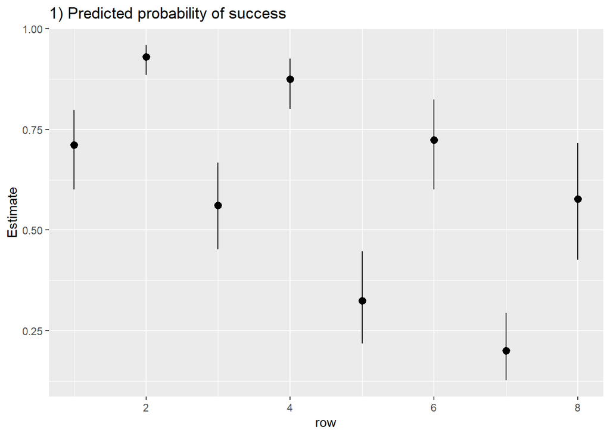

```r
ggplot(data = data.frame(p_i)) +
    geom_pointrange(aes(x = 1:8, y = Estimate, ymin = Q5.5, ymax = Q94.5) ) +
    labs(title = "1) Predicted probability of success") + xlab("row")
```

Then we get the predicted success counts and their respective 89% compatibility intervals for each row $i$:

```r
(successes_i <- predict(m.11H2.1, probs = c(0.055,0.945)))
```

```
##      Estimate Est.Error Q5.5 Q94.5
## [1,] 16.89575  2.685737   12    21
## [2,] 26.89250  1.547431   24    29
## [3,] 15.06100  3.165246   10    20
## [4,] 17.38250  1.653595   15    20
## [5,]  3.97275  1.833671    1     7
## [6,] 11.54325  2.115833    8    15
## [7,]  5.72075  2.577776    2    10
## [8,]  2.30950  1.033913    1     4
```

Plot:

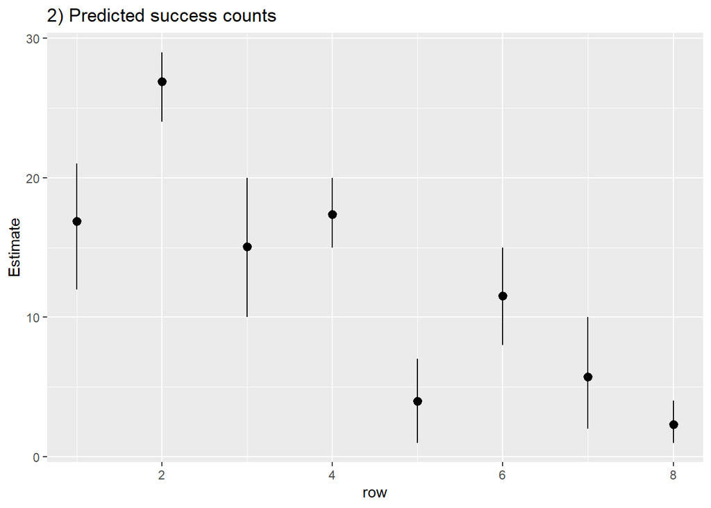

```r
ggplot(data = data.frame(successes_i)) +
    geom_pointrange(aes(x = 1:8, y = Estimate, ymin = Q5.5, ymax = Q94.5) ) +
    labs(title = "2) Predicted success counts") + xlab("row")
```

The predicted probabilities of success provide a measure of how effective each pirate eagle is when trying to steal a salmon from another eagle. The predicted success counts tell us, how many salmon each pirate eagle actually steals, given the attempts it makes.

## (c)

Q: Now try to improve the model. Consider an interaction between the pirate’s size and age (immature or adult). Compare this model to the previous one, using WAIC. Interpret.

A:

To include an interaction between the pirate’s size and age, we fit the following model:
$$\begin{align*}
y_i &\sim {\sf Binomial}(n_i, p_i) \\
{\sf log} {{p_i}\over{1-p_i}} &= \alpha + \beta_P \, P_i + \beta_V \, V_i + \beta_A \, A_i + \beta_{PA} \, P_i \, A_i \\
\alpha &\sim {\sf Normal}(0, 1.5) \\
\beta_P &\sim {\sf Normal}(0, 0.5) \\
\beta_V &\sim {\sf Normal}(0, 0.5) \\
\beta_A &\sim {\sf Normal}(0, 0.5) \\
\beta_{PA} &\sim {\sf Normal}(0, 0.5)
\end{align*}$$

In `brms`:

```r
m.11H2.2 <-
  brm(data = d,
      family = binomial(link = "logit"),
      formula = y | trials(n) ~ 1 + P + V + A + P:A,
      prior = c(prior(normal(0,1.5), class = Intercept),
                prior(normal(0,0.5), class = b)))
```

```r
posterior_summary(m.11H2.2)
```

```
##                Estimate Est.Error       Q2.5       Q97.5
## b_Intercept   0.8514954 0.3041753   0.239462   1.4694441
## b_PS         -1.3133428 0.3472635  -2.007764  -0.6366341
## b_VS          1.6475213 0.3280146   1.014644   2.3056269
## b_AI         -0.3978049 0.3366482  -1.042813   0.2682597
## b_PS:AI      -1.1009030 0.4058008  -1.908945  -0.3059384
## lp__        -36.0164673 1.6514003 -40.114313 -33.8738429
```

Now, there is an additional summand to the log-odds in case that the pirate eagle is both small *and* immature, `b_PS:AI`. Its 95% uncertainty interval lies entirely in the negative, so that this specific interaction reduces the log-odds consistently.

The additional parameter effectively yields a model where all possible combinations of the binary predictors $P$ and $A$ get their unique intercepts, which are then modified homogeneously by the indicator variable $V$. This can be seen as follows:
$${\sf log} {{p_i}\over{1-p_i}} = \alpha + \beta_P \, P_i + \beta_V \, V_i + \beta_A \, A_i + \beta_{PA} \, P_i \, A_i$$

Or, factored differently:
$${\sf log} {{p_i}\over{1-p_i}} = \alpha + \left(\beta_P + \beta_{PA} \, A_i\right) \, P_i + \beta_V \, V_i + \beta_A \, A_i$$

So, $A$ has not only got it’s own effect, it’s also modulating the effect of $P$ (this could be factored the other way round).

Now let’s see the intercepts for the four combinations of $P$ and $A$:

- $P=0$ and $A=0$: ${\sf log} {{p_i}\over{1-p_i}} = \alpha + \beta_V \, V_i$
- $P=0$ and $A=1$: ${\sf log} {{p_i}\over{1-p_i}} = \alpha + \beta_3 + \beta_V \, V_i$
- $P=1$ and $A=0$: ${\sf log} {{p_i}\over{1-p_i}} = \alpha + \beta_1 + \beta_V \, V_i$
- $P=1$ and $A=1$: ${\sf log} {{p_i}\over{1-p_i}} = \alpha + \beta_1 + \beta_3 + \beta_4 + \beta_V \, V_i$

Without $\beta_4$, the intercept for $P=1$ and $A=1$ would be completely determined by the other three scenarios.

Back to the question, computing WAICs:

```r
m.11H2.1 <- add_criterion(m.11H2.1, "waic")
m.11H2.2 <- add_criterion(m.11H2.2, "waic")
```

```
## Warning:
## 5 (62.5%) p_waic estimates greater than 0.4. We recommend trying loo instead.
```

```r
loo_compare(m.11H2.1, m.11H2.2, criterion = "waic")
```

```
##          elpd_diff se_diff
## m.11H2.2  0.0       0.0
## m.11H2.1 -3.9       3.9
```

Looking at these values, there seems to be no clear difference in out-of-sample predictive power between the two models.

However, running `waic()` on the two models spits out some warnings. We can follow its suggestions and compare with `loo()` and `reloo = TRUE`:

```r
m.11H2.1 <- add_criterion(m.11H2.1, "loo", reloo = TRUE)
m.11H2.2 <- add_criterion(m.11H2.2, "loo", reloo = TRUE)
loo_compare(m.11H2.1, m.11H2.2, criterion = "loo")
```

```
##          elpd_diff se_diff
## m.11H2.2  0.0       0.0
## m.11H2.1 -3.6       3.9
```

## Extra: all unique intercepts

Above we saw that adding an interaction between two binary variables effectively adds unique intercepts to specific combinations of values for those variables. By extension, the model where all combinations of all variables where uniquely parameterised is the model including all multi-way interactions (here three 2-way and one 3-way interaction, so 8 parameters in total). This is the same as all variable combinations uniquely parameterised, which we shall look at quickly here out of interest:

```r
# construct unique ID for each combination of variables
d$ix <- factor(seq(1,8,1))

m.11H2.3 <-
  brm(data = d,
      family = binomial(link = "logit"),
      formula = y | trials(n) ~ 0 + ix,
      prior = prior(normal(0,1.5), class = b))
```

```r
summary(m.11H2.3)
```

```
##  Family: binomial
##   Links: mu = logit
## Formula: y | trials(n) ~ 0 + ix
##    Data: d (Number of observations: 8)
## Samples: 4 chains, each with iter = 2000; warmup = 1000; thin = 1;
##          total post-warmup samples = 4000
##
## Population-Level Effects:
##     Estimate Est.Error l-95% CI u-95% CI Rhat Bulk_ESS Tail_ESS
## ix1     0.85      0.43     0.05     1.72 1.00     6627     3153
## ix2     3.22      0.79     1.86     4.92 1.00     5130     3132
## ix3     0.50      0.39    -0.24     1.30 1.00     7027     2999
## ix4     2.95      0.83     1.52     4.76 1.00     5334     2680
## ix5    -1.89      0.73    -3.44    -0.59 1.00     5759     2824
## ix6     2.16      0.75     0.87     3.77 1.00     6012     2804
## ix7    -3.19      0.81    -4.96    -1.80 1.00     5961     3003
## ix8    -0.80      0.90    -2.64     0.92 1.00     5805     2591
##
## Samples were drawn using sampling(NUTS). For each parameter, Bulk_ESS
## and Tail_ESS are effective sample size measures, and Rhat is the potential
## scale reduction factor on split chains (at convergence, Rhat = 1).
```

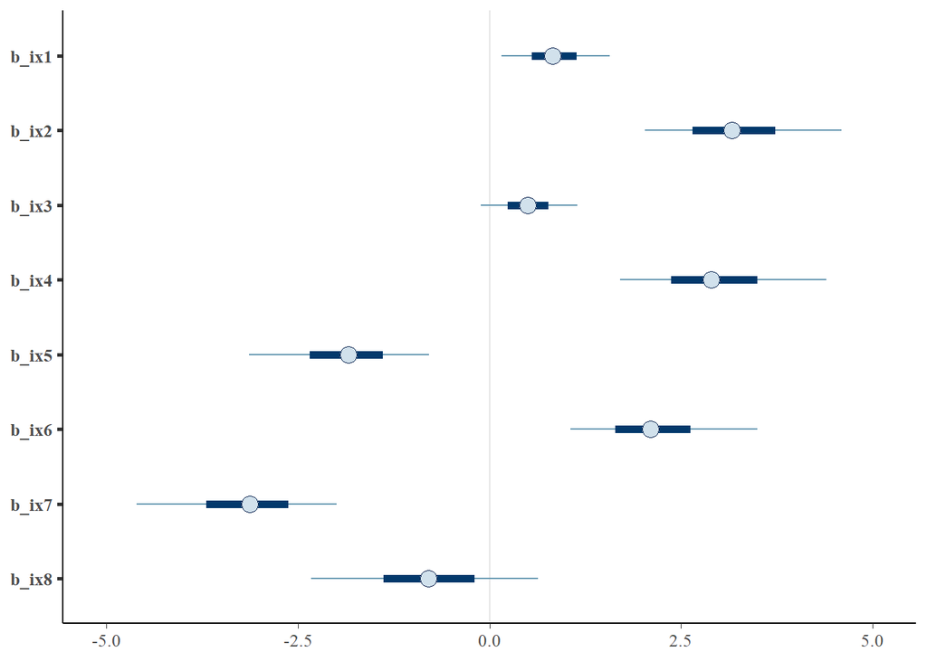

```r
mcmc_plot(m.11H2.3)
```

These unique intercept have the advantage, that each combination of factors has the same prior uncertainty. However, it is a bit more work to decode the indices again and to look at differences between groups.